# Exam 2

BIO 109: Animal and Plant Function

3/9/2020

# Directions

1. Use notes, Google, and Google scholar to complete.
2. Students are encouraged to help each other in the sense of working together to understand a concept or to help a student find a resource. Help does NOT mean giving another student your answer.
3. The final product **must be a single PDF file**. For your illustrations, either insert a photo of the drawing or create the drawing digitally.
4. Send the pdf file to walker@maine.edu by **midnight Friday, March 13**.

# Questions

### 1. Define “essential” in the context of nutrition. Choose one set (“a” or “b”) of follow-up questions

#### a. You have probably heard that vegetarians have to be aware that some plants do not provide “complete protein”. What does “complete protein” mean? Use Google scholar to find a specific example of how a herbivore acquires their daily requirement of all amino acids and summarize in a few sentences here. Cite the paper using the Harvard citation format in Google scholar.

#### b. What is Vitamin C and what is the role of Vitamin C in vertebrate metabolism and skeletal physiology? Use Google scholar to learn about a major group of vertebrates that does not synthesize Vitamin C and summarize this here, including the genetic explanation for why this vertebrate group does not synthesize Vitamin C. Cite the paper using the Harvard citation format in Google scholar.

Essential means that the nutrient is necessary in the diet *because the animal does not synthesize the nutrient or does not synthesize the required daily levels*. Importantly: 1) lots of nutrients are necessary for cell function, for example glucose, **but these are not essential if the nutrient can be synthesized**. And, 2) the nutrients that are essential will differ from species to species. For example, most animal species synthesize ascorbic acid (Vitamin C), so this is not an essential nutrient to these animals, even though it is a critical nutrient for animal function.

1. Complete protein refers to a food source that contains adequate amounts of the nine essential amino acids. Standard nutritional guidelines caution vegetarians to be sure to have a varied plant diet because some plant foods lack complete protein. There is some confusion over this. For example, some people think this means that some plants do not contain all nine essential amino acids. This is wrong. All plants synthsize all twenty protein forming amino acids (which include the nine essential for humans). The issue is that some plant-foods have inadequate amounts of some essential amino acids. This paper has some interesting background: https://pdfs.semanticscholar.org/70a1/e292169eb988eb940f4aa17b5d007b2d28aa.pdf.

It’s mainly herbivore specialists that need special adaptations for acqiring adequate amino acids/protein. One example is aphids, many of which feed almost exclusively on plant phloem (the fluid in a plant for transporting organic molecules, primarly sugar), which is typically very low in protein. Most aphids have an obligate, bacterial endosymbiont of the genus *Buchnera* that supplies the aphid host with esential amino acids and adequate nitrogen (in the form of amino acids). See

Douglas, A.E., 1998. Nutritional interactions in insect-microbial symbioses: aphids and their symbiotic bacteria Buchnera. Annual review of entomology, 43(1), pp.17-37.

2. Vitamin C or L-ascorbic acid is a physiologically important co-enzyme in all animals but is an **essential** nutrient in the groups of animals that do not synthesize the molecule. L-ascorbic acid is synthesized from glucose in a series of steps and the last step in animals is catalyzed by the enzyme L-gulonolactone oxidase (GULO or GLO). In haplorhine primates, which includes monkeys, apes, and humans, the GULO gene is a pseudogene – that is, it has evolved mutations that keep it from being transcribed. Consequently, haplorhine primates do not synthesize Vitamin C.

Drouin, G., Godin, J.R. and Pagé, B., 2011. The genetics of vitamin C loss in vertebrates. Current genomics, 12(5), pp.371-378.

### 2. Draw two diagrams, one of fetal and one of adult circulation through a mammalian heart and clearly define the relative oxygenation of the blood (use measures of PO2 is even better). Why do these differ (not how but why, what is it about a fetus and an adult that requires that they differ)?

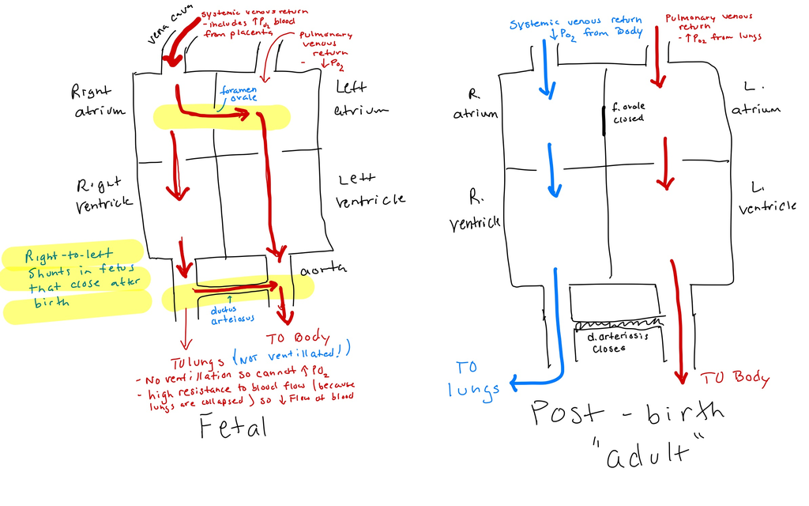

In the adult heart, high PO2 blood from the lung enters the left side of the heart (the left atrium) and is pumped to the body, where O2 diffuses into tissues and plasma PO2 drops. Low PO2 blood from the body returns to the right side of the heart (the right atrium) and is pumped to the lungs, where O2 diffuses from the alveoli into the blood.

*Why* the fetal heart differs: fetal lungs aren’t ventillated so there is no fresh air to supply O2 to the blood. Instead, the placenta is the cite of O2/CO2 exchange. But the placenta doesn’t have its own circuit like the lungs; its part of the systemic circuit. The high PO2 blood from the placenta combines with the low PO2 blood from the other systemic organs and returns to the right side of the heart as intermediate PO2 blood. Since the lung is not ventillated, the intermediate PO2 blood on the right side is *shunted* to the left side (to the systemic circuit), bypassing the pulmonary circuit. The two shunts are the 1) foramen ovale, which is a opening in the wall between the two atria, and the 2) ductus arteriosus, which is a connector between the pulmonary trunk (going to lungs) and the aorta (going to the body).

notes on student answers

1. many students simply copied artists drawing of blood flow through hearts. The anatomical correctness of the picture *gets in the way* of understanding. It was very hard for me to tell if you understood the what is meant by the path of blood flow. To answer a very simple question like that asked only requires a very simple picture. Think abstractly to distill the key elements of an answer and ignore the rest!

### 3. Use Dalton’s law of partial pressure and Henry’s law of the concentration of dissolved gas to describe “the bends”. Use Google scholar to find an example of how a deep diving marine mammal or bird avoids, or minimizes, the bends. What is the behavioral, anatomical, or physiological mechanism of avoidance/minimization. Cite the paper using the Harvard citation format in Google scholar.

Dalton’s and Henry’s laws using N2 as example (because N2 is 80% of air)

Daltons law of PP – $P_{N2} = f_{N2} P_{air}$, where $f_{N2}$ is the fraction of total gas molecules that is N2 and $P_{air}$ is the hydrostatic pressure of air.

Henry’s law – $[N2] = c_{N2} P_{N2}$ where $c_{N2}$ is the solubility coefficient (how soluble the N2 is in body fluid such as plasma)

The partial pressure of N2 in air, which is ~1 atm, is 0.78$\: atm =.78 \cdot 760 \: atm$. The hydrostatic pressure increases about 1 atm per 10 m. So the pressure on a body is about 10X that at the surface at 100 m depth and about 50X at 500 m depth. The increased pressure at depth on the body increases $P_{air}$ in the air spaces of the lung. By Dalton’s law, this increases the $P_{N2}$ in the air spaces. By Henry’s law, this increases the amount of gaseous N2 in the lung that goes into solution – that is, into the plasma and from there into the other fluid compartments (interstitial fluid, intracellular fluid). During the ascent, as the hydrostatic pressure moves to 1 atm, the excess dissolved gas in the plasma/interstitial/intracellular fluid will come out of solution because Henry’s law. This is fine if for the blood in the lungs, as this gas has somewhere to go (the lung air spaces) but in many other parts of the body the spaces aren’t big enough for the air bubbles that emerge and these bubbles block blood flow and tear small vessels and tissues. The illness resulting from this is the bends or decompression sickness.

There are many nice papers describing physiological and behavioral adaptions to deep diving to avoid the bends. A kinda recent review for mammals is:

Hooker, S.K., Fahlman, A., Moore, M.J., Aguilar De Soto, N., Bernaldo de Quirós, Y., Brubakk, A.O., Costa, D.P., Costidis, A.M., Dennison, S., Falke, K.J. and Fernandez, A., 2012. Deadly diving? Physiological and behavioural management of decompression stress in diving mammals. Proceedings of the Royal Society B: Biological Sciences, 279(1731), pp.1041-1050.

Hooker et al review the evidence of two adaptations that were originally thought to prevent the bends (they mitigate but not prevent) and to be universal among diving vertebrates (there is variations)

1. alveolar collapse – essentially alveoli collapse which can 1) drive some air into the “dead space” (non-gas exchange part of respiratory tubes), and 2) decrease surface area and increase respiratory membrane thickness to slow (and ultimately stop) diffusion into blood.
2. diving response – 1) extensive systemic vasoconstriction, which slows blood flow to peripheral organs and 2) extreme bradycardia (slowing of heart rate) – from say 150 bmp to 10 bpm! This will slow cardiac output and flow of blood to tissues.

### 4. What is “osmotic pressure” (a good answer will require an illustration in addition to text)? Use this concept to describe water reabsorption in the collecting duct of the mammal kidney. What is the mechanism that mammals use to control the amount of water reabsorption in the collecting duct (A good answer will include an illustration)

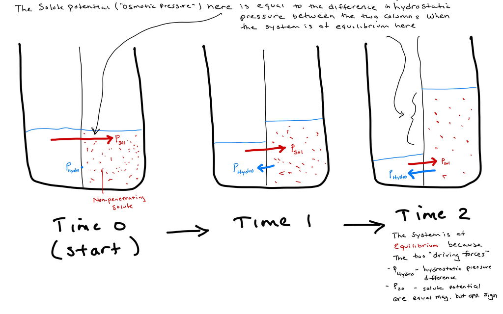

Osmotic pressure is the component of the force driving water across a membrane due to osmosis (the diffusion of water), which occurs when there is a solute concentration difference across the membrane. The Osmotic pressure is equal in magnitude to the hydrostatic force that would be required to balance the diffusion of water, given the solute concentration difference. This concept is illustrated above. The osmotic pressure of the solution on the right-hand-side of the membrane in the left panel is equal to the difference in hydrostatic pressure between the two columns of water in the right side panel.

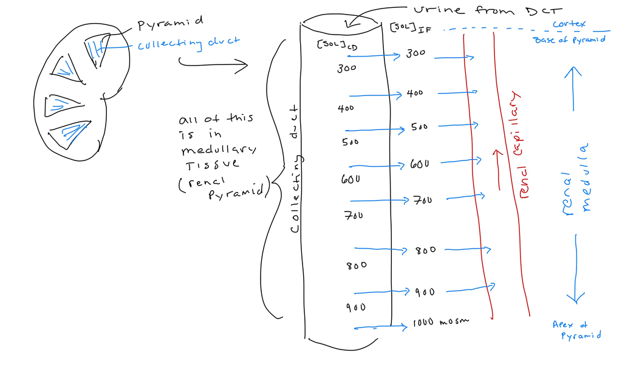

Mammals control the amount of water reabsorbed from the urine by controlling the water permeability of the collecting ducts in the renal pyramids. The collecting ducts collect urine from the nephrons. If the collecting ducts are impermeable to water, the urine passes through and will be very dilute (high water to solute ratio). If the collecting ducts are permeable to water, some fraction of the water is reabsorbed and the urine will be more concentrated (lower water to solute ratio). This mechanism requires:

1. a steep solute concentration gradient of the interstitial fluid (IF) in the medullary tissue (the tissue of the renal pyramid). Osmotic pressure is used to transport water from the collecting duct to the IF. As urine descends in the collecting duct, and water moves from the collecting duct to the IF, the solute concentrat of the urine left in the collecting duct increases and the osmotic pressure decreases to zero. The only way to maintain high osmotic pressure along the entire length of the collecting duct is to maintain a steep solute concentration gradient in the pyramid, from low osmolality at the base to high osmolality at the apex (see image above).
2. hormonal control of water permeability. Antidiuretic hormone controls the concentration of aquaporins on the apical membrane of the collecting duct and this concentration controls the permeability of the epithelium of the collecting duct to water.